# Linear Models in R

Data Science for the Psychological Sciences

Paul D. Kieffaber, Ph.D.

# Introduction to Statistical Modeling

In many fields of research, from psychology and education to medicine and social sciences, the primary goal is to understand and explain relationships between variables. Often, researchers collect data that involves complex relationships, where outcomes (dependent variables) are influenced by several factors (independent variables). Statistical modeling provides the tools needed to quantify these relationships, identify patterns, and make predictions based on data. Without a structured approach to data analysis, researchers risk making inaccurate conclusions, or even worse, overlooking important relationships that could drive insights or interventions.

At its core, statistical modeling is a way of representing data through mathematical equations, allowing researchers to describe, explain, and predict real-world phenomena. These models help simplify complex systems by providing a framework for analyzing the effects of multiple variables simultaneously, while also accounting for random variation and uncertainty. For example, in psychology, statistical models are used to examine how different cognitive, emotional, or environmental factors influence behavior. In education, models might be used to study how teaching methods or school environments affect student performance. In medicine, researchers might use statistical models to identify factors that influence the progression of a disease or the effectiveness of a treatment. And in social sciences, models can help understand complex social behaviors and the impact of policy changes or societal trends.

# The Foundation

### Quantitative Reasoning

The fundamental question of simple linear regression is: How does a continuous outcome variable (Y) change as a continuous predictor variable (X) changes?

We are looking for a linear relationship. We want to find the single straight line that best describes the trend in our data.

*Key Concepts:*

- The Model: Our model for this relationship is a straight line, defined by the formula:

$$Y_i = \beta_0 + \beta_1X_i +
\epsilon_i$$
Let’s break this down:

- $Y_i$ (Outcome): The *i*-th observation of our continuous dependent variable (e.g., the stopping distance for car *i*).
- $X_i$ (Predictor): The *i*-th observation of our continuous independent variable (e.g., the speed of car *i*).
- $\beta_0$ (Intercept): The *parameter* representing the value of $Y$ when $X$ is 0. This is where the line crosses the y-axis.
- $\beta_1$ (Slope): The *parameter* representing the change in $Y$ for a one-unit change in $X$. This is the steepness of the line.
- $\epsilon_i$ (Error/Residual): The *unexplained variance* for the *i*-th observation. This is the vertical distance from the observed data point ($Y_i$) to the line predicted by the model ($\hat{Y}_i$). It’s the part of $Y_i$ that our model *doesn’t* explain.
- Our goal is to find the best possible *estimates* for the unknown parameters $\beta_0$ and $\beta_1$.

*How are the Parameters Solved? (Ordinary Least Squares)*

We find the “best” line using a method called **Ordinary Least Squares (OLS)**. The “best” line is the one that minimizes the total error. Let’s use the built-in R dataset cars (which has speed and stopping dist). We can fit a model and then use ggplot2 to visualize these squared errors that OLS minimizes.

Note that we will need to use R’s conventional model notation to design the linear model. In R, the model describing how variable `Y` is predicted by `X` is designated by `Y ~ X`, which can be verbally described as `Y` is being modeled as a function of `X`.

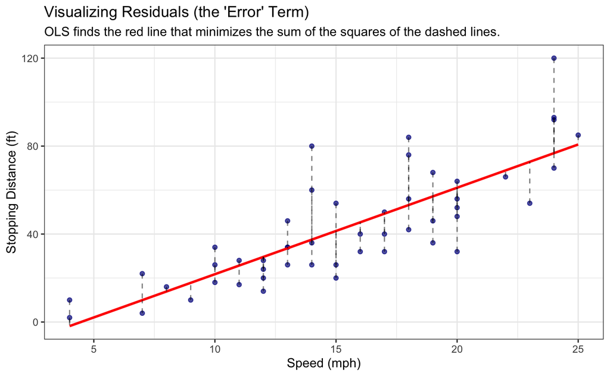

```r
# Use the built-in 'cars' dataset
data(cars)

# 1. Run the linear model
model_cars <- lm(dist ~ speed, data = cars)

# 2. Use broom::augment() to get model results (like .fitted and .resid)
#    back in a data frame with the original data.
model_aug <- broom::augment(model_cars)

# 3. Plot the data, the line, and the residuals
ggplot(model_aug, aes(x = speed, y = dist)) +
  geom_point(color = "darkblue", alpha = 0.7) +  # The raw data points (Y_i)
  geom_smooth(method = "lm", se = FALSE, color = "red") + # The regression line (Y_hat)
  geom_segment(
    aes(xend = speed, yend = .fitted),
    color = "black",
    alpha = 0.5,
    linetype = "dashed"
  ) + # The residuals (epsilon_i)
  labs(
    title = "Visualizing Residuals (the 'Error' Term)",
    subtitle = "OLS finds the red line that minimizes the sum of the squares of the dashed lines.",
    x = "Speed (mph)",
    y = "Stopping Distance (ft)"
  ) +
  theme_bw()
```

Note that some errors ($\epsilon_i$) will be positive (point above the line) and some negative (point below the line). If we just summed them, they would cancel out. To fix this, we **square** each error term. This makes all errors positive and heavily penalizes large mistakes.

OLS finds the specific values of $\beta_0$ and $\beta_1$ that *minimize the sum of the squared residuals (RSS)*.

$$RSS = \sum_{i=1}^{n} \epsilon\_i^2 =
\sum_{i=1}^{n} (Y_i - \hat{Y}_i)^2 = \sum_{i=1}^{n} (Y_i - (\beta_0 +
\beta_1X_i))^2$$

### The Model Parameters

**1. The Slope ($\beta_1$):**

The slope is the covariance of X and Y divided by the variance of X. It measures how much Y changes, on average, for each one-unit change in X.

$$\beta_1 = \frac{\sum_{i=1}^{n} (X_i -
\bar{X})(Y_i - \bar{Y})}{\sum_{i=1}^{n} (X_i - \bar{X})^2} =
\frac{\text{Cov}(X, Y)}{\text{Var}(X)}$$

**2. The Intercept ($\beta_0$):**

Once we have the slope, the intercept is calculated to ensure the line passes through the “center of mass” of the data, which is the point $(\bar{X}, \bar{Y})$ (the mean of X and the mean of Y).

$$\beta_0 = \bar{Y} -
\beta_1\bar{X}$$

## R Implementation

Now, let’s look at how to get the results in R. We use the lm() function, which stands for “linear model”.

We will again need R’s model notation. Recall that the formula `y ~ x` means “y is predicted by x” or “y is modeled as a function of x”.

```r
model_cars <- lm(dist ~ speed, data = cars)

# Use summary() to get the detailed results
summary(model_cars)
```

```
Call:
lm(formula = dist ~ speed, data = cars)

Residuals:
    Min      1Q  Median      3Q     Max
-29.069  -9.525  -2.272   9.215  43.201

Coefficients:
            Estimate Std. Error t value Pr(>|t|)
(Intercept) -17.5791     6.7584  -2.601   0.0123 *
speed         3.9324     0.4155   9.464 1.49e-12 ***
---
Signif. codes:  0 ‘***’ 0.001 ‘**’ 0.01 ‘*’ 0.05 ‘.’ 0.1 ‘ ’ 1

Residual standard error: 15.38 on 48 degrees of freedom
Multiple R-squared:  0.6511,    Adjusted R-squared:  0.6438
F-statistic: 89.57 on 1 and 48 DF,  p-value: 1.49e-12
```

**Reading the summary() Output**

The most important part is the Coefficients table.

- `(Intercept)`: This is our $\beta_0 = -17.58$. This means at 0 mph, the model predicts a stopping distance of -17.58 ft. This is a good example of an intercept that is not practically meaningful (you can’t have negative distance), but it is mathematically necessary to position the line correctly.
- `speed` Estimate: This is our $\beta_1 = 3.93$. This is the key result! For every 1 mph increase in speed, the model predicts a 3.93 ft increase in stopping distance.
- `Pr(>|t|)` (p-value): This is the p-value for the hypothesis test.

### Hypothesis Testing

For our slope, the null hypothesis ($H_0$) is that there is no relationship:

$H_0: \beta_1 = 0$

The alternative hypothesis ($H_a$) is that there is a relationship:

$H_a: \beta_1 \neq 0$

Our p-value for speed is 1.49e-12, which is extremely small (0.00000000000149). This is much less than our standard significance level of $\alpha = 0.05$.

**Conclusion:** We reject the null hypothesis and conclude that there is a statistically significant positive linear relationship between speed and stopping distance.

### Final Visualization

Finally, we create our publication-quality graph. geom_smooth(method = “lm”) will run the exact same OLS regression for us and plot the line, including a 95% confidence interval by default.

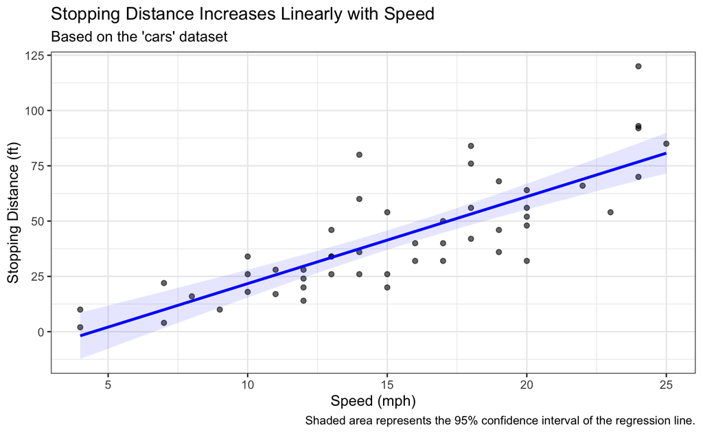

```r
# Now, the plot code you provided, with the annotation added
ggplot(cars, aes(x = speed, y = dist)) +
  geom_point(alpha = 0.6) +
  geom_smooth(method = "lm", color = "blue", fill = "blue", alpha = 0.1) +
  labs(
    title = "Stopping Distance Increases Linearly with Speed",
    subtitle = "Based on the 'cars' dataset",
    x = "Speed (mph)",
    y = "Stopping Distance (ft)",
    caption = "Shaded area represents the 95% confidence interval of the regression line."
  ) +
  theme_bw()
```

**Tips & Tricks - Accessing Data in Model Output**

The `summary()` output is great for humans, but hard for R to use. The broom package helps. Below are some examples of how you would go about accessing data from the model outputs.

```r
# --- Create APA Annotation ---
summary_cars=summary(model_cars)
# 1. Extract R-squared
r_squared <- summary_cars$r.squared


# 2. Extract the F-statistic and degrees of freedom
f_stat <- summary_cars$fstatistic
f_value <- f_stat[1]
df1 <- f_stat[2]
df2 <- f_stat[3]

# 3. Get the model's p-value from the F-statistic
# We can't just pull it from the summary easily.
# This is where broom comes in handy...
lm_result=broom::tidy(model_cars)
p_value <- lm_result %>% filter(term == "speed") %>% pull(p.value)

# 4. Format p-value using scales::pvalue()
p_formatted <- scales::pvalue(p_value, accuracy = 0.001)

# 5. Create the APA output
apa_annotation <- paste0(sprintf("R^2= %.2f | F(%.i,%.i)=%.2f, p%s", r_squared, df1, df2, f_value, p_formatted))
print(apa_annotation)

broom::tidy(model_cars)
```

# The t-test & Regression

Now that we have a solid foundation in simple linear regression, our next step is to see how this framework is far more powerful than it first appears. We’ll start with one of the most common statistical tests: the t-test. Although t-tests are almost always taught as a separate tool for comparing two groups, they are, in fact, just another special case of the General Linear Model. This section will connect the dots and show you how running a t-test is mathematically identical to running a regression with a single, two-level categorical predictor.

### Quantitative Reasoning (QR)

The quantitative question for a two-sample t-test is simple: Is the mean of a continuous variable (Y) different between two groups (A and B)?

Our standard null hypothesis ($H_0$) is that the means are the same:

$$H_0: \mu_A = \mu_B$$

And our alternative hypothesis ($H_a$) is that they are not:

$$H_a: \mu_A \neq \mu_B$$

This is the exact same question we can ask (and answer) using linear regression.

**The Conceptual Link: Dummy Coding**

To see how this works, we have to revisit our regression model from Part 1:

$$Y_i = \beta_0 + \beta_1X_i +
\epsilon_i$$
Earlier, $X$ was continuous (like `speed`). Now, $X$ is a **categorical predictor** (a factor) with two levels, “Group A” and “Group B”.

A computer can’t “do math” on a text string like “Group A”. To solve this, R (and all statistical software) performs **dummy coding** under the hood. It creates a new numeric variable, let’s call it $X_{dummy}$, that represents the group:

1. **Reference Group:** R first picks one level as the “reference” group. This is usually the level that comes first alphabetically (e.g., “Group A”). This group gets a value of 0.
- If `Group` is “Group A”, then $X_{dummy} = 0$
2. **Contrast Group:** The other group gets a value of 1.
- If `Group` is “Group B”, then $X_{dummy} = 1$

Now, let’s plug this dummy variable $X_{dummy}$ into our regression equation and see what happens for each group.

**Case 1: A person in “Group A” ($X_{dummy} = 0$)**

The model for any person in Group A becomes:

$$Y\_i = \beta\_0 + \beta\_1(0) +
\epsilon\_i
\\
Y\_i = \beta\_0 + \epsilon\_i$$

This means that, *on average*, the predicted value for a person in Group A is just $\beta_0$. Therefore, **$\beta_0$ (the intercept) is the mean of the reference group (Group A).**

$$\beta_0 = \mu_A$$

**Case 2: A person in “Group B” ($X_{dummy} = 1$)**

The model for any person in Group B becomes:

$$Y_i = \beta_0 + \beta_1(1) +
\epsilon_i$$
$$Y_i = (\beta_0 +
\beta_1) + \epsilon_i$$

This means the predicted value for a person in Group B is $\beta_0 + \beta_1$. We already know $\beta_0 = \mu_A$, so:

$$\mu_B = \mu_A + \beta_1$$
If we rearrange that, we get the meaning of $\beta_1$:

$$\beta\_1 = \mu\_B - \mu\_A$$
Therefore, **$\beta_1$ (the slope) is the *difference* between the mean of Group B and the mean of Group A.**

**A-ha! Moment**

Now, look at the null hypothesis for our regression model:

$H_0: \beta_1 = 0$

If we substitute what we just learned about what $\beta_1$ means:

$H_0: (\mu_B - \mu_A) = 0$

…which is the same as:

$H_0: \mu_B = \mu_A$

This is the **identical null hypothesis** from our t-test. The regression model is literally testing if the difference in means is equal to zero.

## R Implementation:

Let’s prove this using the built-in `ToothGrowth` dataset. It has a continuous outcome `len` (tooth length) and a 2-level factor `supp` (supplement type: “VC” or “OJ”).

```r
# Let's use the ToothGrowth dataset
data(ToothGrowth)
str(ToothGrowth)

# R will automatically make "OJ" the reference group because it's first alphabetically.
# To make it clearer, let's re-level 'supp' so "VC" is the reference.
ToothGrowth$supp <- factor(ToothGrowth$supp, levels = c("VC", "OJ"))
levels(ToothGrowth$supp)
```

### The Traditional Way: `t.test()`

Let’s run a standard t-test. **NOTE**, we must set `var.equal = TRUE`. A standard `lm()` model assumes *homoscedasticity* (equal variances), just like a Student’s t-test.

```r
# Run the t-test, assuming equal variances
ttest_result <- t.test(len ~ supp, data = ToothGrowth, var.equal = TRUE)
ttest_result
```

Look at the key results:

- **t-statistic:** -1.915
- **p-value:** 0.06039
- **Difference in means (`mean(VC) - mean(OJ)`):** -3.7

### The GLM Way: `lm()`

Now, let’s run the exact same analysis as a linear model.

```r
model_t <- lm(len ~ supp, data = ToothGrowth)
summary(model_t)
```

Now, look at the `Coefficients:` table, specifically the row for `suppOJ` (this is $\beta_1$, the coefficient for the “OJ” group):

- **`Estimate`:** 3.700
- **`t value`:** 1.915
- **`Pr(>|t|)`:** 0.06039

### Compare The Outputs

[output not shown]

```
It matches exactly.
```

This shows that a t-test is just a special case of a linear regression where the predictor variable is a two-level factor.

## Visualization (`ggplot2`)

For this kind of data, a boxplot with jittered raw data points is perfect. It shows the distribution (the box) and the individual observations (the points).

```r
ggplot(ToothGrowth, aes(x = supp, y = len, fill = supp)) +
  geom_boxplot(alpha = 0.5, outlier.shape = NA) +
  geom_jitter(width = 0.1, height = 0, alpha = 0.7) +
  # We can also add points for the means, which is what the model estimates
  stat_summary(
    fun = "mean",
    geom = "point",
    shape = "X",
    size = 5,
    color = "red"
  ) +
  geom_smooth(method = "lm", color = "blue", fill = "blue", alpha = 0.1,
              aes(group=1) #need to tell geom_smooth to use all points.
              ) +
  labs(
    title = "Tooth Growth by Supplement Type",
    subtitle = "A t-test is just a regression on these two groups.",
    x = "Supplement Type",
    y = "Tooth Length (len)",
    fill = "Supplement"
  ) +
  theme_bw()
```

# ANOVA is also a Regression

In the last section, we saw how a two-group t-test is just a special case of a linear model. Now, we’ll extend that same exact logic to situations with three or more groups. This is the foundation of ANOVA (Analysis of Variance), and as we’ll see, it’s still just a linear regression using a slightly more complex set of dummy variables.

## Quantitative Reasoning

The quantitative question for a one-way ANOVA (Analysis of Variance) is: Is the mean of a continuous variable (Y) different among three or more groups (e.g., A, B, C)?

The traditional ANOVA null hypothesis ($H_0$) is that all group means are equal:

$H_0: \mu_A = \mu_B = \mu_C$

The alternative hypothesis ($H_a$) is that at least one group mean is different from the others.

Once again, we can answer this exact question using our friend, the General Linear Model (GLM).

**The Conceptual Link:** More Dummy Variables

When we had two groups (Part 2), R created one dummy variable ($X_1$). When we have k groups, R creates k-1 dummy variables.

Let’s stick with our 3-group example (A, B, C).

- Reference Group: R picks one level as the reference (e.g., “Group A”).
- Dummy Variables: R creates one dummy variable for each other group.

$X_1$ (let’s call it groupB): = 1 if the person is in Group B, 0 otherwise.

$X_2$ (let’s call it groupC): = 1 if the person is in Group C, 0 otherwise.

Now our regression model looks like this:

$$Y_i = \beta_0 + \beta_1X_1 + \beta_2X_2
+ \epsilon_i$$
Let’s plug in the dummy codes to see what each coefficient means.

*Case 1: A person in “Group A” (Reference)*

For this person, $X_1 = 0$ and $X_2 = 0$.

$$Y\_i = \beta\_0 + \beta\_1(0) +
\beta\_2(0) + \epsilon\_i
\\
Y\_i = \beta\_0 + \epsilon\_i$$
This means the predicted value for a person in Group A is just $\beta_0$.

**Conclusion: $\beta_0$ (the intercept) is the mean of the reference group (Group A).**

$$\beta_0 = \mu_A$$

*Case 2: A person in “Group B”*

For this person, $X_1 = 1$ and $X_2 = 0$.

$$Y_i = \beta_0 + \beta_1(1) + \beta_2(0)
+ \epsilon_i
\\
Y_i = (\beta_0 + \beta_1) + \epsilon_i$$

The predicted value is $\beta_0 + \beta_1$. Since we know $\beta_0 = \mu_A$: Conclusion: $\beta_1$ is the difference between the mean of Group B and the mean of Group A.

$$\beta_1 = \mu_B - \mu_A$$
### Case 3: A person in “Group C”

For this person, $X_1 = 0$ and $X_2 = 1$.

$$Y\_i = \beta\_0 + \beta\_1(0) +
\beta\_2(1) + \epsilon\_i
\\
Y\_i = (\beta\_0 + \beta\_2) + \epsilon\_i$$

The predicted value is $\beta_0 + \beta_2$.

**Conclusion: $\beta_2$ is the *difference* between the mean of Group C and the mean of Group A.**

$$\beta_2 = \mu_C - \mu_A$$

## The “A-ha!” Moment: summary() vs. anova()

This is the most critical concept in this section. When you run lm() with a factor, you get two different ways to see the results, and they answer different questions.

We’ll use the built-in iris dataset. We want to know if Sepal.Length is different among the three Species.

```r
# 'iris' is built-in
data(iris)
str(iris) # Species is a 3-level factor

# Run the linear model
model_aov <- lm(Sepal.Length ~ Species, data = iris)
```

## 1. The summary() Output (The t-tests)

Let’s look at the summary() first.

```r
summary(model_aov)
```

The Coefficients: table shows you the $\beta$ estimates.

`(Intercept)`: 5.006. This is $\beta_0$, the mean Sepal.Length for the reference group (setosa).

`Speciesversicolor`: 0.930. This is $\beta_1$, the difference between versicolor and setosa ($\mu_{versicolor} - \mu_{setosa}$).

`Speciesvirginica`: 1.582. This is $\beta_2$, the difference between virginica and setosa ($\mu_{virginica} - \mu_{setosa}$).

Question Answered by summary(): The p-values here are for t-tests comparing each group to the reference.

“Is versicolor different from setosa?” (p < 8.77e-16). Yes.

“Is virginica different from setosa?” (p < 2e-16). Yes.

Missing Question: This output does not tell us if versicolor and virginica are different from each other!

## 2. The anova() Output (The F-test)

Now, let’s run the anova() function on the same model.

```r
anova(model_aov)
```

This gives the classic ANOVA table. The key line is the Species row.

F value: 119.27

Pr(>F): < 2.2e-16

Question Answered by anova(): This F-test answers the overall ANOVA question: “Does the Species variable as a whole explain a significant amount of variance in Sepal.Length?” Or, “Is there any difference among the means of setosa, versicolor, and virginica?” The p-value (p < 2.2e-16) says Yes, absolutely.

This F-test is comparing your full model (lm(Sepal.Length ~ Species)) against a “null” model that only has an intercept (lm(Sepal.Length ~ 1)), which is just the grand mean.

In short:

summary(model): Gives you the coefficients (t-tests vs. reference group).

anova(model): Gives you the overall F-test (are there differences between groups?).

### How the F-test Comparison Works

The F-test is a model comparison. It compares two models:

- The Full Model: model_aov <- lm(Sepal.Length ~ Species, data = iris)
  - This model “believes” that the Species groups are different. Its “prediction” for any point is the mean of that point’s species group (e.g., 5.006 for setosa, 5.936 for versicolor).
- The Null Model: model_null <- lm(Sepal.Length ~ 1, data = iris)
  - This is the model that “believes” the null hypothesis ($H_0: \mu_A = \mu_B = \mu_C$) is true.
  - The ~ 1 formula tells lm() to fit an intercept-only model. The single best prediction for all points, if you can’t use Species, is the grand mean of all Sepal.Length data.

The F-test calculates the error (Sum of Squares) for both models.

- Error (Full Model): The sum of squared distances from each point to its group mean (SS_Residuals or SS_Within).
- Error (Null Model): The sum of squared distances from each point to the grand mean (SS_Total).

The F-test asks: “Is the reduction in error we get by using the Full Model significantly better than the simple Null Model, after accounting for the extra ‘degrees of freedom’ we spent?”

### Illustrating the Model Comparison in R

Let’s prove this. We can build the null model ourselves and manually compare it to our full model.

```r
# 1. Build the null model (intercept-only)
model_null <- lm(Sepal.Length ~ 1, data = iris)

# 2. Look at its summary
summary(model_null)
```

```r
# 3. Prove the intercept is the grand mean
mean(iris$Sepal.Length)
```

As you can see, the Intercept (5.8433) is exactly the grand mean of Sepal.Length.

Now, let’s use the anova() function to explicitly compare the two models:

```r
# Compare the null model (model_null) to the full model (model_aov)
anova(model_null, model_aov)
```

Now, let’s look at the output of anova(model_aov) again…

```r
anova(model_aov)
```

Look at that output! It is the identical ANOVA table we got from just running anova(model_aov).

Res.Df (Residual Df)

RSS (Residual Sum of Squares)

Df (Degrees of Freedom for the Species term)

Sum of Sq (Sum of Squares for the Species term)

F (F-value)

Pr(>F) (p-value)

This proves that calling anova(model_aov) is just a shortcut for building an intercept-only null model and comparing it to your full model.

In short:

summary(model): Gives you the coefficients (t-tests vs. reference group).

anova(model): Gives you the overall F-test by comparing your model to a null (grand mean) model.

## Visualization (ggplot2)

As before, a boxplot with jittered points is perfect. Let’s add the “Null Model” (grand mean) to our plot to visualize the comparison.

```r
# Let's prove our coefficient logic
iris_means <- iris %>%
group_by(Species) %>%
summarise(mean_sepal_len = mean(Sepal.Length))
print(iris_means)
# Note: setosa mean is 5.006 (our Intercept)
# versicolor mean is 5.936. 5.936 - 5.006 = 0.930 (our Speciesversicolor coef)
# virginica mean is 6.588.  6.588 - 5.006 = 1.582 (our Speciesvirginica coef)

# Get the grand mean for our plot
grand_mean <- mean(iris$Sepal.Length)

ggplot(iris, aes(x = Species, y = Sepal.Length, fill = Species)) +
geom_boxplot(alpha = 0.4, outlier.shape = NA) +
geom_jitter(width = 0.1, alpha = 0.5) +

# This is the "Full Model" prediction (the group means)
stat_summary(
fun = "mean",
geom = "point",
shape = "X",
size = 5,
color = "black"
) +
geom_smooth(method = "lm", color = "blue", fill = "blue", alpha = 0.1,
        aes(group=1) #need to tell geom_smooth to use all points.
        ) +

# This is the "Null Model" prediction (the grand mean)
geom_hline(
yintercept = grand_mean,
linetype = "dashed",
color = "red",
size = 1.2
) +

# Label the grand mean line
annotate(
"text",
x = "setosa",
y = grand_mean + 0.15,
label = "Grand Mean (Null Model)",
color = "red",
hjust = "left"
) +

labs(
title = "Sepal Length by Iris Species",
subtitle = "F-test compares the fit of the 'Full Model' (group means, 'x') vs. the 'Null Model' (grand mean line).",
x = "Species",
y = "Sepal Length (cm)"
) +
theme_bw() +
theme(legend.position = "none") # The x-axis already has the info
```

### From Two General Linear Models to F-values & P-values

The p-value for the overall ANOVA comes from an F-statistic. This F-statistic is fundamentally a ratio that answers the question:“How much better is our ‘Full Model’ at explaining the data than a simple ‘Null Model’?”

Here’s the breakdown:

**Step 1: Define the Two Models and Their Errors**

- The Null Model (Model 0 or “Intercept-Only”)Formula: lm(y ~ 1)
  - Hypothesis: This model represents the “Null Hypothesis” ($H_0$). It assumes all group means are the same.
  - Prediction: Its single best prediction for every data point is the Grand Mean ($\bar{Y}_{total}$).
  - Error (SSE_0): The error for this model is the “Total Sum of Squares” (SST). It’s the sum of the squared distances from every point to the Grand Mean.

  $$SSE_0 = \sum (Y_i -
  \bar{Y}_{total})^2$$
- The Full Model (Model 1 or “Groups Model”)Formula: lm(y ~ group)
  - Hypothesis: This model represents the “Alternative Hypothesis” ($H_a$). It assumes the group means are different.
  - Prediction: Its “best” prediction for a data point is the mean of that point’s own group ($\bar{Y}_{group(i)}$).Error (SSE_1): The error for this model is the “Sum of Squared Errors” (SSE) or “Sum of Squares Within” (SSW). It’s the sum of the squared distances from every point to its group mean.

  $$SSE_1 = \sum (Y_i -
  \bar{Y}_{group(i)})^2$$

**Step 2: Calculate the “Mean Squares” (the Variances)**

The F-statistic doesn’t just compare the total error; it compares the average error (the variance, or “Mean Square”), which accounts for how many predictors we added.

- Mean Square Error (MSE): This is the residual, unexplained variance from our “Full Model”. It’s the $SSE_1$ averaged by its degrees of freedom ($df_1$). $df_1 = n - k$ (where $n$ is sample size, $k$ is number of groups).

$$MSE = \frac{SSE_1}{n-k}$$

- Mean Square Model (MSM): This is the variance explained by our “Full Model”. It’s the reduction in error from Model 0 to Model 1, averaged by the number of “parameters” we spent to get that reduction ($df_{model}$).$df_{model} = df_0 - df_1 = (n-1) - (n-k) = k-1$.

$$MSM = \frac{SSE_0 -
SSE_1}{k-1}$$

**Step 3: Calculate the F-statistic**

The F-statistic is the ratio of the explained variance to the unexplained variance.

$$F = \frac{\text{Variance Explained by
Groups}}{\text{Variance Unexplained (Residual)}} =
\frac{MSM}{MSE}$$
If the groups explain a lot of variance (MSM is big) and the residual variance is small (MSE is small), the F-statistic will be large. If the groups explain no more variance than random chance, $MSM \approx MSE$, and the F-statistic will be close to 1.0.

**Step 4: Find the p-value (The Connection to Normality)**

To know if our F-value (e.g., F = 119) is “big”, we need to compare it to a null distribution. Under the null hypothesis, the F-statistic follows a specific F-distribution.This mathematical F-distribution is defined by its two degrees of freedom, $df_1 = k-1$ and $df_2 = n-k$.

But why? The F-distribution is, by definition, the ratio of two independent chi-squared ($\chi^2$) distributions.

- MSE (the denominator) can be shown to be a $\chi^2$ variable… IF the things we are squaring to get it, the residuals ($Y_i - \bar{Y}_{group(i)}$), are normally distributed.
- MSM (the numerator) can also be shown to be a $\chi^2$ variable… IF those same residuals are normally distributed.

This is the key: The entire F-test, which gives us our p-value, is only mathematically valid if the residuals ($\epsilon_i$) are normally distributed. The p-value, then, is the probability of getting an F-statistic as large as (or larger than) the one we calculated, assuming the null hypothesis is true. A huge F-value (like 119) is so far in the tail of the F-distribution that its probability (p-value) is tiny, leading us to reject the null model.